# QTM 350 Final Project – School Enrollment Trends Analysis

Authors

Da Eun Kim (2483332)

Alix Morales (2594298)

Katie Park (2563640)

Yoonsuh Park (2499926)

Published

December 9, 2024

# 1 Introduction

Education is a cornerstone of sustainable development, playing a pivotal role in shaping economic and social outcomes. School enrollment rates, which measure access to education at primary, secondary, and tertiary levels, serve as critical indicators of a country’s progress toward achieving universal education. This project explores global patterns and disparities in school enrollment using data from the World Bank’s World Development Indicators (WDI) database. By examining trends over time, identifying leading and lagging countries, and analyzing regional differences, this study sheds light on the successes and persistent challenges in global education systems.

Focusing on three key indicators—primary enrollment (% gross), secondary enrollment (% gross), and tertiary enrollment (% gross)—this analysis investigates the relationships between education levels and their evolution over time. Additionally, it evaluates how regions and countries vary in their educational performance, highlighting areas for policy intervention. This study aims to provide actionable insights into the state of global education, contributing to the broader discourse on achieving equitable and inclusive access to quality education worldwide.

# 2 Data Description

This dataset is a long-format representation of World Development Indicators (WDI), capturing socio-economic and developmental statistics across multiple countries and regions. It includes 664 entries spanning a range of indicators, such as school enrollment rates at different educational levels. The data consists of seven columns: `country_name`, `country_code`, `series_name` (indicator name), `series_code` (indicator code), `year`, `value` (observed statistic), and `region` (geographical classification). Each row corresponds to a specific indicator for a country in a given year, making it suitable for time-series analysis and cross-country comparisons. The dataset provides insights into regional and global trends, supporting research on education, economic development, and social progress.

Primary Enrollment (% gross): Indicator code SE.PRM.ENRR. Secondary Enrollment (% gross): Indicator code SE.SEC.ENRR. Tertiary Enrollment (% gross): Indicator code SE.TER.ENRR. Countries and Regions: Data is available for countries worldwide, categorized into regions such as “South Asia,” “Sub-Saharan Africa,” etc. Years: The dataset includes time-series data, enabling the analysis of enrollment trends over time. Variables: The dataset contains numerical values for enrollment rates (value) along with metadata such as country name, region, and year. The dataset has been cleaned for consistency: no missing values were observed in key columns, and all columns have appropriate data types.

# 3 Data Analysis

```python
import pandas as pd
wdi_data = pd.read_csv("wdi_data_with_region.csv")
```

## 3.1 Global Trends in School Enrollment Over Time

This analysis examines the global trends in gross enrollment rates across primary, secondary, and tertiary education levels over time. By grouping data by year and indicator, we calculate global averages and plot these trends.

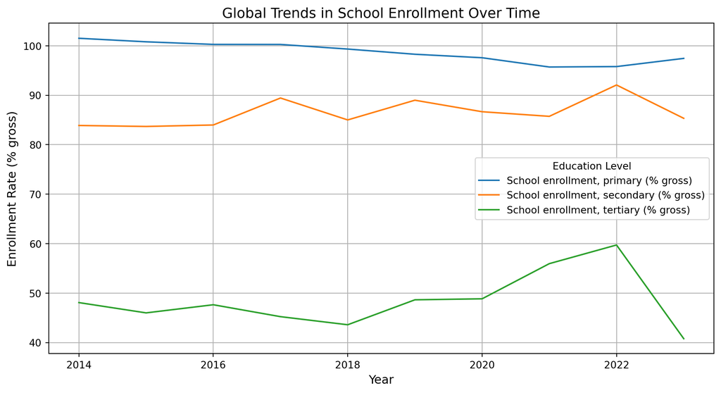

```python
#1. Global Trends in School Enrollment Over Time
import matplotlib.pyplot as plt

# Extract relevant indicators for analysis

relevant_indicators = ['SE.PRM.ENRR', 'SE.SEC.ENRR', 'SE.TER.ENRR']

filtered_data = wdi_data[wdi_data['series_code'].isin(relevant_indicators)]

# Group by year and calculate global averages for each indicator

trend_data = filtered_data.groupby(['year', 'series_name'])['value'].mean().reset_index()

# Plot trends over time

plt.figure(figsize=(12, 6))

for indicator in trend_data['series_name'].unique():
    indicator_data = trend_data[trend_data['series_name'] == indicator]
    plt.plot(indicator_data['year'], indicator_data['value'], label=indicator)

plt.title('Global Trends in School Enrollment Over Time', fontsize=14)
plt.xlabel('Year', fontsize=12)
plt.ylabel('Enrollment Rate (% gross)', fontsize=12)
plt.legend(title='Education Level')
plt.grid(True)
plt.show()
```

## 3.2 Regional Comparison of Mean Enrollment Rates by Indicator

This analysis compares average enrollment rates by education level (primary, secondary, tertiary) across different regions. By calculating mean rates per region, the bar chart highlights disparities in education access.

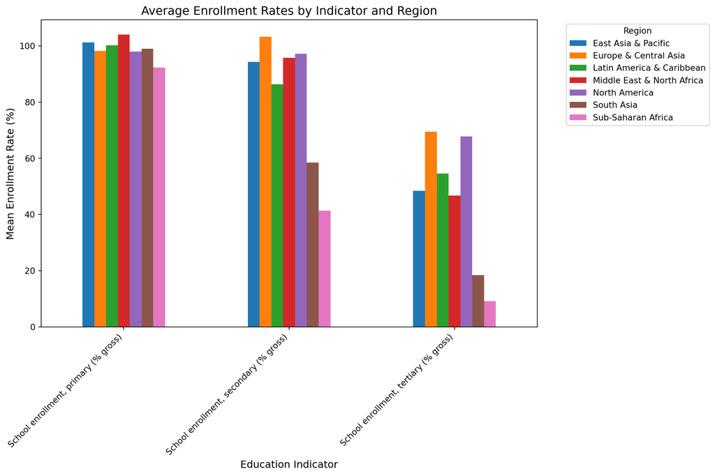

```python
#2. Regional Comparison of Mean Enrollment Rates by Indicator

indicator_region_averages = wdi_data.groupby(['series_name', 'region'])['value'].mean().unstack()
indicator_region_averages.plot(kind='bar', figsize=(12, 8))
plt.title("Average Enrollment Rates by Indicator and Region", fontsize=14)
plt.xlabel("Education Indicator", fontsize=12)
plt.ylabel("Mean Enrollment Rate (%)", fontsize=12)
plt.xticks(rotation=45, ha='right')
plt.legend(title='Region', bbox_to_anchor=(1.05, 1), loc='upper left')
plt.tight_layout()
plt.show()
```

## 3.3 Correlation Between Primary, Secondary, and Tertiary Enrollment

This analysis explores the relationship between enrollment rates at primary, secondary, and tertiary levels. A heatmap visualizes Pearson correlation coefficients.

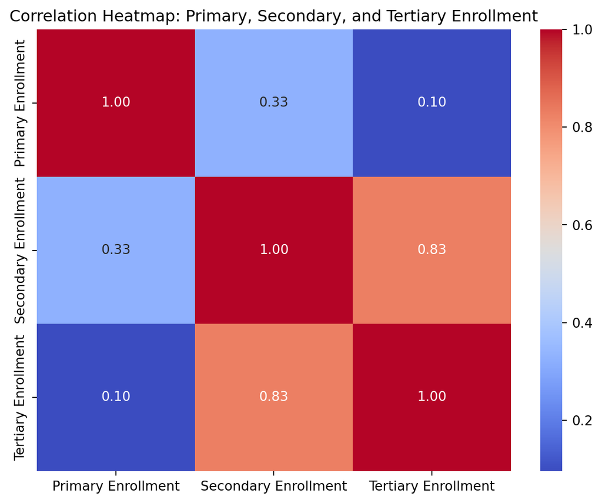

```python
#3. Correlation Between Primary, Secondary and Tertiary Indictors

# Filter data to include only relevant indicators
filtered_data = wdi_data[wdi_data['series_name'].isin([
    'School enrollment, primary (% gross)',
    'School enrollment, secondary (% gross)',
    'School enrollment, tertiary (% gross)'
])]

# Pivot data to have indicators as columns
pivoted_data = filtered_data.pivot_table(
    index=['country_name', 'year'],
    columns='series_name',
    values='value'
).dropna()

# Rename columns for easier reference
pivoted_data.columns = ['Primary Enrollment', 'Secondary Enrollment', 'Tertiary Enrollment']

# Calculate Pearson correlation coefficients
correlation_matrix = pivoted_data.corr()

import seaborn as sns

# Plotting the correlation heatmap
plt.figure(figsize=(8, 6))
sns.heatmap(correlation_matrix, annot=True, fmt=".2f", cmap="coolwarm", cbar=True)
plt.title("Correlation Heatmap: Primary, Secondary, and Tertiary Enrollment")
plt.show()
```

# 4 Results and Discussion

## 4.2 Regional Comparison of Mean Enrollment Rates by Indicator

- Developed Regions: Tend to have high enrollment rates across all levels, indicating well-established education systems.
- Developing Regions: Display gaps, especially in secondary and tertiary levels, pointing to challenges like economic barriers and lack of infrastructure.
- Notable Gaps: Sub-Saharan Africa and South Asia show significantly lower tertiary enrollment rates, emphasizing regional inequalities.

Such comparisons underline the need for targeted policies to address disparities and improve access in underperforming regions.

# 5 Conclusion

In conclusion, the analysis of global school enrollment trends provides valuable insights into the progress and challenges in achieving universal education. Primary education exhibits consistently high enrollment rates, reflecting global commitments to foundational education access. However, the disparities in secondary and tertiary enrollment highlight persistent inequalities, particularly in developing regions such as Sub-Saharan Africa and South Asia. These disparities emphasize the need for targeted policy interventions, such as improving education infrastructure, addressing economic barriers, and enhancing teacher training.

By shedding light on these patterns, this study underscores the importance of data-driven approaches to education policymaking. Future research could expand on this analysis by exploring the impact of socioeconomic factors, gender disparities, and digital access on enrollment trends, offering a more holistic view of global education systems.